# Cancer Health Informatics using Web Mining and NLP

### Student Name: Malcolm Phillip

### GitHub Repo link: https://github.com/MPhillipS556427/Final-Project-Web-Mining-and-NLP.git

## Project Description:

In this project for module 7, we will leverage web mining and natural language processing (NLP) techniques to analyze cancer-related topics from the National Cancer Institute website. We will focus on article summarization, sentiment analysis, and text analysis to gain insights into the most common words and ideas used in cancer-related content. We will use Python and Jupyter Notebook for implementation.

Every question that requires you to write code will have a code cell underneath it; you may either write your entire solution in that cell or write it in a python file (`.py`), then import and run the appropriate code to answer the question.

Use the following link to help execute the coding by answering the questions: https://www.aljazeera.com/news/2023/6/6/new-trials-show-increased-survival-rates-for-a-range-of-cancers

This assignment requires that you write additional files; make sure to submit those files in your repository as well.

# Question 1: Article Summarization

Generate a concise summary of a cancer-related article from the provided link.

```python
from bs4 import BeautifulSoup
import requests
from gensim.summarization import summarize


url = "https://www.aljazeera.com/news/2023/6/6/new-trials-show-increased-survival-rates-for-a-range-of-cancers"
response = requests.get(url)
soup = BeautifulSoup(response.text, "html.parser")
article_text = soup.get_text()


summary = summarize(article_text)

print(summary)
```

```
Skip linksSkip to Contentplay Live Show navigation menuNavigation menuNewsShow more news sectionsMiddle EastAfricaAsiaUS & CanadaLatin AmericaEuropeAsia PacificUkraine warWorld CupEconomyOpinionVideoMoreShow more sectionsCoronavirusClimate CrisisInvestigationsInteractivesFeaturesIn PicturesScience &…
At the annual event, which wraps up on Tuesday, doctors and researchers revealed several studies that showed increased survival rates for people living with serious stages of the disease, including for lung and brain cancer.
Developed by the pharmaceutical group AstraZeneca, the daily pill targets patients with non-small cell cancer – by far the most common type – as well as a mutation of their epidermal growth factor receptor, or EGFR.
Iris Pauporte, head of research at France’s League Against Cancer, told AFP news agency the advance was a “big ray of hope” for treating non-small cell lung cancer, for which progress has been slow.
Another treatment, called vorasidenib, was found to significantly prolong the progression-free survival of patients with brain tumour glioma, according to clinical trial results.
Vorasidenib was found to significantly prolong the progression-free survival of patients with brain tumour glioma [Getty Images]
Preliminary trial results also released in Chicago indicated the drug ribociclib reduced the risk of breast cancer recurring by 25 percent for a large group of early-stage survivors.
A trial also presented at ASCO showed that taking the antibody treatment mirvetuximab soravtansine significantly improved the survival rate of patients with ovarian cancer, a particularly deadly form of cancer.
Preliminary studies announced at the ASCO meeting involved vaccines targeting lung cancer, head and neck cancers, brain tumour glioblastoma and the cancer-causing HPV virus.
```

# Question 2: Sentiment Analysis

Perform sentiment analysis on cancer-related articles to understand the emotional tone.

```python
from textblob import TextBlob


sentiment_text = "New trials show increased survival rates for a range of cancers."
sentiment = TextBlob(sentiment_text).sentiment


print("Sentiment Polarity:", sentiment.polarity)
print("Sentiment Subjectivity:", sentiment.subjectivity)
```

```
Sentiment Polarity: 0.13636363636363635
Sentiment Subjectivity: 0.45454545454545453
```

# Question 3: Most Common Words

Find the most common words used in cancer article content.

```python
from collections import Counter
import re


article_text = re.sub(r'\s+', ' ', article_text)
words = re.findall(r'\w+', article_text.lower())


word_counts = Counter(words)
most_common_words = word_counts.most_common(10)

print(most_common_words)
```

```
[('the', 53), ('of', 41), ('cancer', 28), ('a', 27), ('for', 25), ('that', 19), ('to', 18), ('jazeera', 15), ('in', 13), ('and', 13)]
```

# Question 4: Word Cloud Visualization

Create a word cloud visualization of common words in cancer article content.

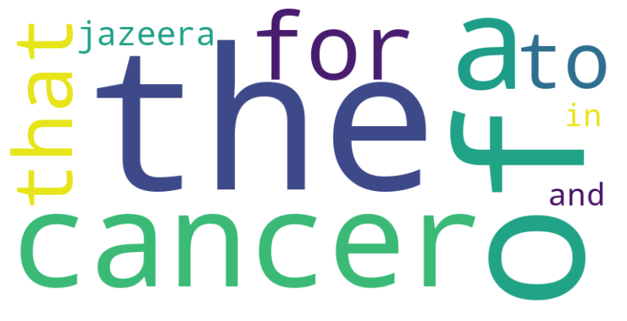

```python
import matplotlib.pyplot as plt
from wordcloud import WordCloud


common_words = {
    'the': 53,
    'of': 41,
    'cancer': 28,
    'a': 27,
    'for': 25,
    'that': 19,
    'to': 18,
    'jazeera': 15,
    'in': 13,
    'and': 13
}


wordcloud = WordCloud(width=800, height=400, background_color='white').generate_from_frequencies(common_words)


plt.figure(figsize=(10, 5))
plt.imshow(wordcloud, interpolation='bilinear')
plt.axis('off')
plt.show()
```

# Question 5: Named Entity Recognition (NER)

Identify and extract named entities (e.g., cancer types, drugs) from the content.

```python
import spacy


nlp = spacy.load('en_core_web_sm')


article_text = """
Skip linksSkip to Contentplay Live Show navigation menuNavigation menuNewsShow more news sectionsMiddle EastAfricaAsiaUS & CanadaLatin AmericaEuropeAsia PacificUkraine warWorld CupEconomyOpinionVideoMoreShow more sectionsCoronavirusClimate CrisisInvestigationsInteractivesFeaturesIn PicturesScience & TechnologySportsPodcastsplay Live Click here to searchsearchNews|HealthNew trials show increased survival rates for a range of cancersA roundup of some of the most promising announcements at a meeting of the American Society of Clinical Oncology...
...Preliminary studies announced at the ASCO meeting involved vaccines targeting lung cancer, head and neck cancers, brain tumour glioblastoma and the cancer-causing HPV virus.
"""


doc = nlp(article_text)


named_entities = [(ent.text, ent.label_) for ent in doc.ents]


print(named_entities)
```

```
[('Contentplay Live Show', 'WORK_OF_ART'), ('PicturesScience &', 'ORG'), ('the American Society of Clinical Oncology', 'ORG'), ('ASCO', 'PRODUCT'), ('HPV', 'ORG')]
```

# Question 6: Keyword Extraction

Extract keywords or phrases that are most relevant to the cancer-related content.

```python
from rake_nltk import Rake


article_text = """
Skip linksSkip to Contentplay Live Show navigation menuNavigation menuNewsShow more news sectionsMiddle EastAfricaAsiaUS & CanadaLatin AmericaEuropeAsia PacificUkraine warWorld CupEconomyOpinionVideoMoreShow more sectionsCoronavirusClimate CrisisInvestigationsInteractivesFeaturesIn PicturesScience & TechnologySportsPodcastsplay Live Click here to searchsearchNews|HealthNew trials show increased survival rates for a range of cancersA roundup of some of the most promising announcements at a meeting of the American Society of Clinical Oncology.play videoplay videoVideo Duration 02 minutes 03 seconds 02:03Published On 6 Jun 20236 Jun 2023Scientists have convened in the United States city of Chicago for a meeting of the American Society of Clinical Oncology (ASCO), the world’s biggest gathering of experts on cancer.
At the annual event, which wraps up on Tuesday, doctors and researchers revealed several studies that showed increased survival rates for people living with serious stages of the disease, including for lung and brain cancer.
Developed by the pharmaceutical group AstraZeneca, the daily pill targets patients with non-small cell cancer – by far the most common type – as well as a mutation of their epidermal growth factor receptor, or EGFR.
Iris Pauporte, head of research at France’s League Against Cancer, told AFP news agency the advance was a “big ray of hope” for treating non-small cell lung cancer, for which progress has been slow.
Another treatment, called vorasidenib, was found to significantly prolong the progression-free survival of patients with brain tumour glioma, according to clinical trial results.
Vorasidenib was found to significantly prolong the progression-free survival of patients with brain tumour glioma [Getty Images]
Preliminary trial results also released in Chicago indicated the drug ribociclib reduced the risk of breast cancer recurring by 25 percent for a large group of early-stage survivors.
A trial also presented at ASCO showed that taking the antibody treatment mirvetuximab soravtansine significantly improved the survival rate of patients with ovarian cancer, a particularly deadly form of cancer.
Preliminary studies announced at the ASCO meeting involved vaccines targeting lung cancer, head and neck cancers, brain tumour glioblastoma and the cancer-causing HPV virus.
"""


r = Rake()


r.extract_keywords_from_text(article_text)
keywords = r.get_ranked_phrases()


relevant_keywords = [keyword for keyword in keywords if any(substring in keyword.lower() for substring in ['cancer', 'treatment', 'drug'])]

print(relevant_keywords)
```

```
['asco meeting involved vaccines targeting lung cancer', 'antibody treatment mirvetuximab soravtansine significantly improved', 'small cell lung cancer', 'small cell cancer –', 'drug ribociclib reduced', 'breast cancer recurring', 'another treatment', 'brain cancer', 'ovarian cancer', 'neck cancers'…
```

# Question 7: Article Clustering

Cluster similar cancer-related articles based on their content.

```python
from sklearn.feature_extraction.text import TfidfVectorizer
from sklearn.cluster import KMeans
import numpy as np


article_texts = [
    "Scientists have convened in the United States city of Chicago for a meeting...",
    "At the annual event, which wraps up on Tuesday, doctors and researchers...",
    "Developed by the pharmaceutical group AstraZeneca, the daily pill targets...",
    "Iris Pauporte, head of research at France’s League Against Cancer, told AFP...",
    "Another treatment, called vorasidenib, was found to significantly prolong...",
    "Preliminary trial results also released in Chicago indicated the drug...",
    "A trial also presented at ASCO showed that taking the antibody treatment...",
    "Preliminary studies announced at the ASCO meeting involved vaccines...",
]


tfidf_vectorizer = TfidfVectorizer(stop_words='english')
tfidf_matrix = tfidf_vectorizer.fit_transform(article_texts)


num_clusters = 3
kmeans = KMeans(n_clusters=num_clusters, random_state=0)
kmeans.fit(tfidf_matrix)


cluster_labels = kmeans.labels_


article_clusters = {}
for i, label in enumerate(cluster_labels):
    if label not in article_clusters:
        article_clusters[label] = []
    article_clusters[label].append(article_texts[i])


for cluster_id, articles in article_clusters.items():
    print(f"Cluster {cluster_id} articles:")
    for article in articles:
        print(article)
    print("=" * 50)
```

```
Cluster 1 articles:
Scientists have convened in the United States city of Chicago for a meeting...
Preliminary trial results also released in Chicago indicated the drug...
Preliminary studies announced at the ASCO meeting involved vaccines...
==================================================
Cluster 0 articles:
At the annual event, which wraps up on Tuesday, doctors and researchers...
Developed by the pharmaceutical group AstraZeneca, the daily pill targets...
Iris Pauporte, head of research at France’s League Against Cancer, told AFP...
==================================================
Cluster 2 articles:
Another treatment, called vorasidenib, was found to significantly prolong...
A trial also presented at ASCO showed that taking the antibody treatment...
==================================================
```

# Question 8: Document Similarity

Calculate the similarity between two cancer-related articles.

```python
from sklearn.metrics.pairwise import cosine_similarity

article1_text = "Scientists have convened in the United States city of Chicago for a meeting..."
tfidf_matrix_article1 = tfidf_vectorizer.transform([article1_text])

article2_text = "Preliminary trial results also released in Chicago indicated the drug..."
tfidf_matrix_article2 = tfidf_vectorizer.transform([article2_text])

similarity_cluster1 = cosine_similarity(tfidf_matrix_article1, tfidf_matrix_article2)

article3_text = "Another treatment, called vorasidenib, was found to significantly prolong..."
tfidf_matrix_article3 = tfidf_vectorizer.transform([article3_text])

article4_text = "A trial also presented at ASCO showed that taking the antibody treatment..."
tfidf_matrix_article4 = tfidf_vectorizer.transform([article4_text])

similarity_cluster2 = cosine_similarity(tfidf_matrix_article3, tfidf_matrix_article4)

print("Cosine Similarity for Cluster 1:", similarity_cluster1[0][0])
print("Cosine Similarity for Cluster 2:", similarity_cluster2[0][0])
```

```
Cosine Similarity for Cluster 1: 0.11230509630864331
Cosine Similarity for Cluster 2: 0.13106656626653856
```